# Summarising measurement use in a dataset

# Introduction

In this vignette we will see how we can summarise the use of measurement concepts in our dataset as a whole. For our example we’re going to be interested in measurement concepts related to respiratory function and will use the Eunomia synthetic dataset.

First we will connect to the database and create a cdm reference.

```r
library(duckdb)
library(omopgenerics)
library(CDMConnector)
library(dplyr)
```

```r
con <- dbConnect(duckdb(), dbdir = eunomiaDir())
```

```
#> Creating CDM database
#> /var/folders/33/ny_t5lgj0mv3slx4bb7gd1wh0000gr/T//Rtmp232ucv/GiBleed_5.3.zip
```

```r
cdm <- cdmFromCon(
  con = con, cdmSchem = "main", writeSchema = "main", cdmName = "Eunomia"
)
cdm
```

```
#>
#> ── # OMOP CDM reference (duckdb) of Eunomia ────────────────────────────────────
#> • omop tables: care_site, cdm_source, concept, concept_ancestor, concept_class,
#> concept_relationship, concept_synonym, condition_era, condition_occurrence,
#> cost, death, device_exposure, domain, dose_era, drug_era, drug_exposure,
#> drug_strength, fact_relationship, location, measurement, metadata, note,
#> note_nlp, observation, observation_period, payer_plan_period, person,
#> procedure_occurrence, provider, relationship, source_to_concept_map, specimen,
#> visit_detail, visit_occurrence, vocabulary
#> • cohort tables: -
#> • achilles tables: -
#> • other tables: -
```

## Defining a codelist of measurements

Now we’ll create a codelist with measurement concepts.

```r
respiratory_function_codes <- newCodelist(list(
  "respiratory_function" = c(4052083L, 4133840L, 3011505L)
))
respiratory_function_codes
```

```
#>
#> - respiratory_function (3 codes)
```

For a general summary of the use of these codes in our dataset we can use `summariseCodeUse` from the [**CodelistGenerator**](https://darwin-eu.github.io/CodelistGenerator/) R package.

```r
library(CodelistGenerator)
code_use <- summariseCodeUse(respiratory_function_codes, cdm)
tableCodeUse(code_use)
```

| Codelist name | Standard concept name | Standard concept ID | Source concept name | Source concept ID | Source concept value | Type concept id | Type concept name | Domain ID | Table | Database name Eunomia Estimate name Record count | Database name Eunomia Estimate name Person count |
| --- | --- | --- | --- | --- | --- | --- | --- | --- | --- | --- | --- |
| respiratory_function | overall | – | NA | NA | NA | NA | NA | NA | NA | 8,728 | 2,096 |
|  | Measurement of respiratory function | 4052083 | Measurement of respiratory function | 4052083 | 23426006 | 5001 | NA | measurement | measurement | 4,088 | 2,072 |
|  | FEV1/FVC | 3011505 | FEV1/FVC | 3011505 | 19926-5 | 5001 | NA | measurement | measurement | 2,320 | 125 |
|  | Spirometry | 4133840 | Spirometry | 4133840 | 127783003 | 5001 | NA | measurement | measurement | 2,320 | 125 |

While this provides a useful high-level summary, more detailed information is often needed to assess study feasibility and design.

## Measurement diagnostics

The **MeasurementDiagnostics** package provides additional, measurement-specific diagnostic checks. Specifically, it includes three types of diagnostics:

1. `measurement_summary`: summarises the number of subjects with measurements, the number of measurements per subject, and the time between measurements.
2. `measurement_value_as_number`: summarises measurement values recorded as numeric values, providing descriptive statistics by measurement unit.
3. `measurement_value_as_concept`: summarises measurement values recorded as concepts and their frequencies.

These diagnostics can be performed using the `summariseMeasurementUse()` function.

```r
library(MeasurementDiagnostics)

respiratory_function_measurements <- summariseMeasurementUse(
  cdm = cdm,
  codes = respiratory_function_codes
)
```

As with some other OMOP analytical packages, results are returned in the `summarised_result` format defined by the [**omopgenerics**](https://darwin-eu.github.io/omopgenerics/) package.

```r
respiratory_function_measurements |>
  glimpse()
```

```
#> Rows: 2,116
#> Columns: 13
#> $ result_id        <int> 1, 1, 1, 1, 1, 1, 1, 1, 1, 1, 1, 1, 1, 1, 1, 1, 1, 1,…
#> $ cdm_name         <chr> "Eunomia", "Eunomia", "Eunomia", "Eunomia", "Eunomia"…
#> $ group_name       <chr> "codelist_name", "codelist_name", "codelist_name", "c…
#> $ group_level      <chr> "respiratory_function", "respiratory_function", "resp…
#> $ strata_name      <chr> "overall", "overall", "overall", "overall", "overall"…
#> $ strata_level     <chr> "overall", "overall", "overall", "overall", "overall"…
#> $ variable_name    <chr> "number_subjects", "days_between_measurements", "days…
#> $ variable_level   <chr> NA, NA, NA, NA, NA, NA, "density_001", "density_001",…
#> $ estimate_name    <chr> "count", "min", "q25", "median", "q75", "max", "densi…
#> $ estimate_type    <chr> "integer", "integer", "integer", "integer", "integer"…
#> $ estimate_value   <chr> "2096", "0", "0", "371", "1726", "33541", "0", "0.000…
#> $ additional_name  <chr> "overall", "overall", "overall", "overall", "overall"…
#> $ additional_level <chr> "overall", "overall", "overall", "overall", "overall"…
```

## Visualise results

For each diagnostic check, the package provides both **table** and **plot** functions. For example, the following table displays results from the `measurement_summary` check:

```r
tableMeasurementSummary(respiratory_function_measurements)
```

| CDM name | Codelist name | Variable name | Estimate name | Estimate value |
| --- | --- | --- | --- | --- |
| Eunomia | respiratory_function | Number subjects | N (%) | 2,096 (77.80%) |
|  |  | Days between measurements | Median [Q25 – Q75] | 371 [0 – 1,726] |
|  |  |  | Range | 0 to 33,541 |
|  |  | Measurements per subject | Median [Q25 – Q75] | 2.00 [1.00 – 3.00] |
|  |  |  | Range | 1.00 to 138.00 |

To learn more about available tables and plots, see the vignette *“Results Visualisation”*.

# Stratifications

By default, `summariseMeasurementUse()` stratifies results by codelist only. That is, all checks are returned for the overall codelist, and the value-based checks (`measurement_value_as_number` and `measurement_value_as_concept`) are further stratified by individual measurement concepts.

However, results can also be stratified by sex, year of measurement, and age group at measurement date In the following example, we generate `measurement_value_as_number` results stratified by sex and two different age group definitions.

```r
results <- summariseMeasurementUse(
  cdm = cdm,
  codes = respiratory_function_codes,
  byConcept = FALSE,
  byYear = FALSE,
  bySex = TRUE,
  ageGroup = list(
    age_group_narrow = list(c(0, 19), c(20, 39), c(40, 59), c(60, 79), c(80, 150)),
    age_group_broad = list(c(0, 17), c(18, 64), c(65, 150))
  ),
  checks = "measurement_value_as_number"
)

# Show results stratified by broad age group
results |>
  filterStrata(age_group_broad != "overall") |>
  tableMeasurementValueAsNumber(
    header = "age_group_broad",
    groupColumn = character(),
    hide = c("age_group_narrow", "sex", "variable_level")
  )
```

| CDM name | Codelist name | Unit concept name | Unit concept ID | Variable name | Estimate name | Age group broad 0 to 17 | Age group broad 18 to 64 | Age group broad 65 to 150 |
| --- | --- | --- | --- | --- | --- | --- | --- | --- |
| Eunomia | respiratory_function | No matching concept | 0 | Measurement records | N | 1,396 | 5,787 | 1,545 |
|  |  |  |  | Value as number | Median [Q25 – Q75] | – | – | – |
|  |  |  |  |  | Q05 – Q95 | – | – | – |
|  |  |  |  |  | Q01 – Q99 | – | – | – |
|  |  |  |  |  | Range | – | – | – |
|  |  |  |  |  | Missing value, N (%) | 1,396 (100.00%) | 5,787 (100.00%) | 1,545 (100.00%) |

# Estimates

By default, each diagnostic check produces a predefined set of estimates. These can be modified using the estimates argument.

The default estimates are:

**1. measurement_summary:** `"min"`, `"q25"`, `"median"`, `"q75"`, `"max"`, `"density"`

**2. measurement_value_as_number:** `"min"`, `"q01"`, `"q05"`, `"q25"`, `"median"`, `"q75"`, `"q95"`, `"q99"`, `"max"`, `"count_missing"`, `"percentage_missing"`, `"density"`

**3. measurement_value_as_concept:** `"count"`, `"percentage"`

Allowed estimates depend on the type of variable being summarised. For example, `measurement_value_as_concept` only supports categorical estimates, whereas the others use numeric estimates (as variables are numeric, e.g. time between measurements).

Available estimates are defined in the [**PatientProfiles**](https://darwin-eu.github.io/PatientProfiles/) package. To see all supported estimates and their naming conventions, use `availableEstimates()` from that package. Note that only categorical estimates are allowed for `measurement_value_as_concept`, while the other checks only allow estimates for numeric variable types.

In the following example, we run all checks without density estimates and with a reduced set of quantiles:

```r
results <- summariseMeasurementUse(
  cdm = cdm,
  codes = respiratory_function_codes,
  estimates = list(
    measurement_summary = c("min", "q25", "median", "q75", "max"),
    measurement_value_as_number = c(
      "min", "q25", "median", "q75", "max",
      "count_missing", "percentage_missing"
    ),
    measurement_value_as_concept = c("count", "percentage")
  )
)

results |>
  tableMeasurementValueAsNumber()
```

| CDM name | Concept name | Concept ID | Source concept name | Source concept ID | Domain ID | Unit concept name | Unit concept ID | Variable name | Estimate name | Estimate value |
| --- | --- | --- | --- | --- | --- | --- | --- | --- | --- | --- |
| respiratory_function |  |  |  |  |  |  |  |  |  |  |
| Eunomia | overall | overall | overall | overall | overall | No matching concept | 0 | Measurement records | N | 8,728 |
|  |  |  |  |  |  |  |  | Value as number | Median [Q25 – Q75] | – |
|  |  |  |  |  |  |  |  |  | Range | – |
|  |  |  |  |  |  |  |  |  | Missing value, N (%) | 8,728 (100.00%) |
|  | Measurement of respiratory function | 4052083 | Measurement of respiratory function | 4052083 | Measurement | No matching concept | 0 | Measurement records | N | 4,088 |
|  |  |  |  |  |  |  |  | Value as number | Median [Q25 – Q75] | – |
|  |  |  |  |  |  |  |  |  | Range | – |
|  |  |  |  |  |  |  |  |  | Missing value, N (%) | 4,088 (100.00%) |
|  | FEV1/FVC | 3011505 | FEV1/FVC | 3011505 | Measurement | No matching concept | 0 | Measurement records | N | 2,320 |
|  |  |  |  |  |  |  |  | Value as number | Median [Q25 – Q75] | – |
|  |  |  |  |  |  |  |  |  | Range | – |
|  |  |  |  |  |  |  |  |  | Missing value, N (%) | 2,320 (100.00%) |
|  | Spirometry | 4133840 | Spirometry | 4133840 | Measurement | No matching concept | 0 | Measurement records | N | 2,320 |
|  |  |  |  |  |  |  |  | Value as number | Median [Q25 – Q75] | – |
|  |  |  |  |  |  |  |  |  | Range | – |
|  |  |  |  |  |  |  |  |  | Missing value, N (%) | 2,320 (100.00%) |

## Histogram estimates

Histogram-style summaries can be obtained using the `histogram` argument. This allows users to specify custom bins for the following variables:

- `"days_between_measurements"`
- `"measurements_per_subject"`
- `"value_as_number"`

In the example below, we generate histogram summaries for days between measurements and measurements per subject using custom bandwidths.

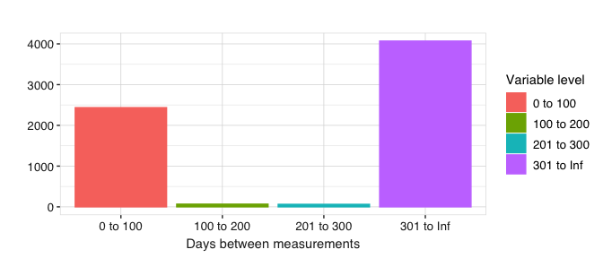

```r
results <- summariseMeasurementUse(
  cdm = cdm,
  codes = respiratory_function_codes,
  estimates = NULL,
  histogram = list(
    "days_between_measurements" = list(
      '0 to 100' = c(0, 100), '100 to 200' = c(101, 200),
      '201 to 300' = c(201, 300), '301 to Inf' = c(301, Inf)
    ),
    "measurements_per_subject" = list(
      '0 to 1' = c(0, 1), '2 to 3' = c(2, 3),
      '4 to 5' = c(4, 5), '6 to 7' = c(6, 7),
      '8+' = c(8, 1000)
    )
  )
)

results |>
  plotMeasurementSummary(
    x = "variable_level",
    plotType = "barplot",
    colour = "variable_level"
  )
```

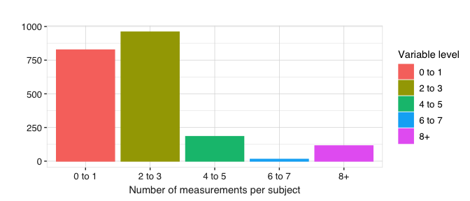

```r
results |>
  plotMeasurementSummary(
    x = "variable_level",
    y = "measurements_per_subject",
    plotType = "barplot",
    colour = "variable_level"
  )
```

Note that density and histogram estimates do not appear in tables, these are just visualised in plot functions by using the plot types “densityplot” and “barplot” respectively.

# Other arguments

The study period can be restricted using the `dateRange` argument. In addition, to reduce computational time, diagnostics are by default performed on a random sample of 20,000 persons. This sample size can be modified using `personSample`, or sampling can be disabled entirely by setting `personSample = NULL`.